# Wenas modeling fire severity figures

PR

2023-06-27

### Description

This markdown is mostly just a script to create two figures for the Wenas model outputs. Doing this in markdown because 1) good to document decisions more thoroughly/readably than in comments, and 2) people seem to love RMD for some reason. I don’t get it…

**IMPORTANT: if source files change, change eval to TRUE for the `Pull data from G Drive` chunk to pull updated data!**

First up, let’s download the data from Drive to local so we can work with it. We’ll put it in pr_work/data/new_model. Note that I’m commenting this one out to speed up rerunning the script

```
## [1] "71 files downloaded"
```

Now that we’ve downloaded files, let’s start working with the percentage burned files, which all contain the string “*PER*”. We are using both means and medians to understand changes, because they differ markedly. At some point as the story coalesces, one will be scrapped / sent to supplemental. We’ll start by making a dataset that contains actual values (not percent changes). Here, we use base_unburned as a common reference (represented as a horizontal line).

Let’s format our dataset for plotting and construct plots

### Median plots for changes based on fire severity

This figure is saved as “pr_work/figures/230627_severity_medians.png”

**NOTE: final figures will also be saved to “../figures/..”

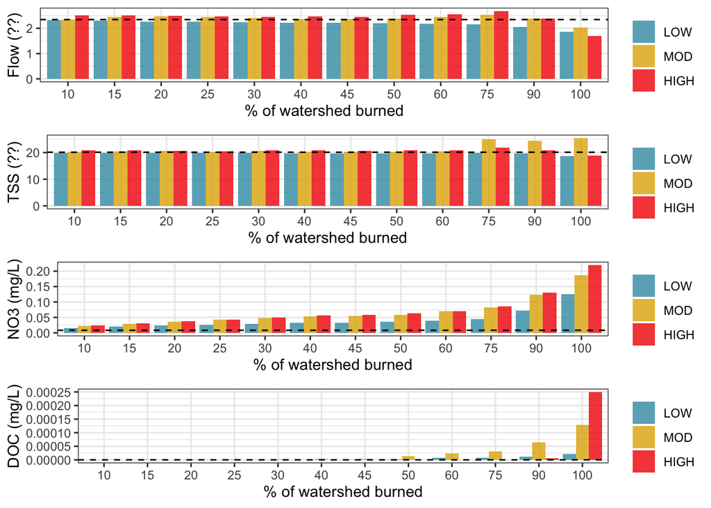

### Mean plots for changes based on fire severity

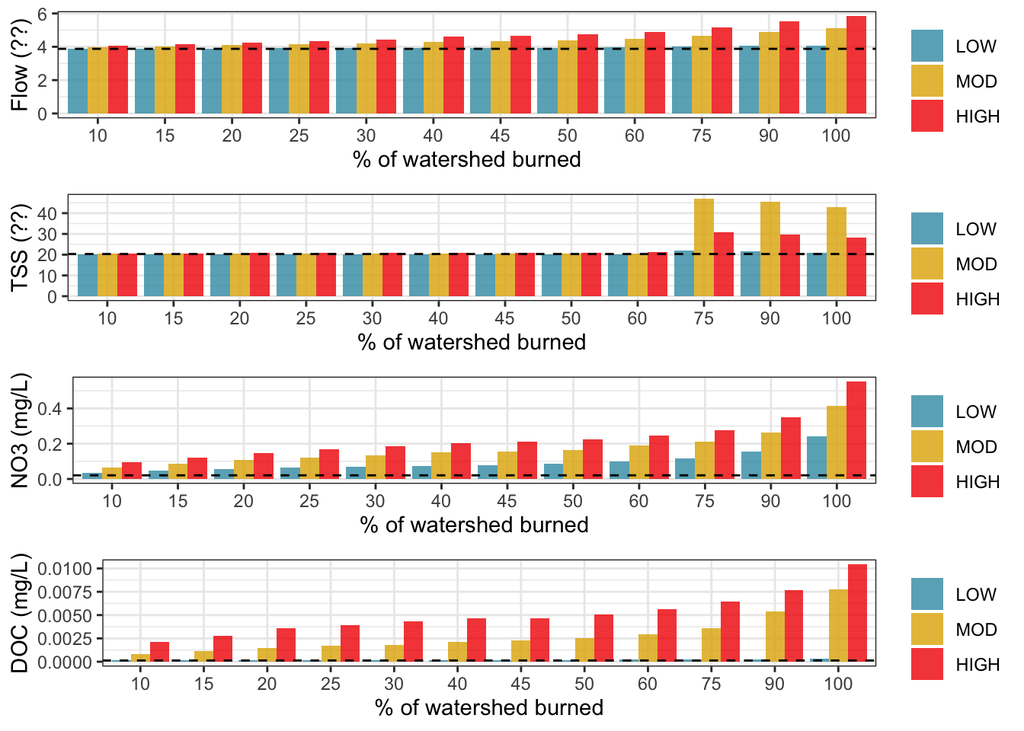

### % change figures

We also want to calculate percent changes because this is the metric that we’ll be using to visualize changes in the other scenarios, which don’t have a common unburned reference value like burn severity. First, we’ll need to calculate % differences, then we’ll create equivalent plots to those above. We’ll use a standardized percent change calculation of **Percent Change: ( Burn - Original ) / Original * 100**

### Plot % change by median

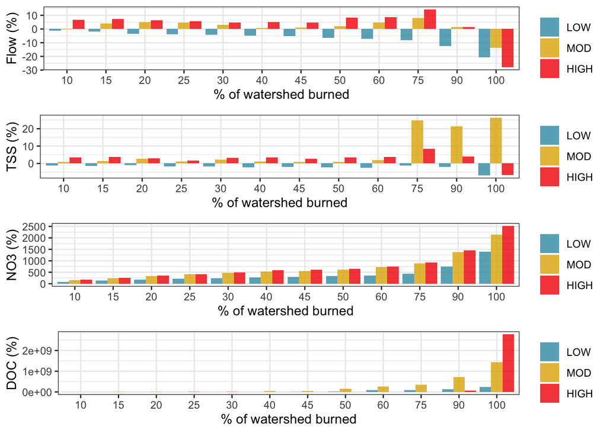

### Plot % change by mean

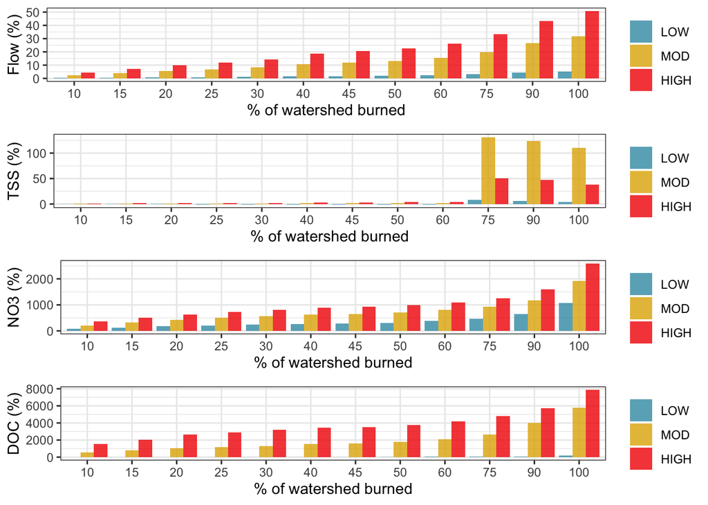